# Simulation of maximum plausible SMD given scale range-to-SD ratio

Ian Hussey

23 February, 2026

# Motivation and logic

## The problem

When evaluating the plausibility of reported effect sizes in psychology — whether for forensic purposes, meta-analytic quality control, or power analysis — it is useful to know the *maximum* standardized mean difference (SMD, Cohen’s *d*) that could plausibly be observed on a given self-report scale. A reported *d* that exceeds this ceiling should raise red flags, because it implies a mean difference that the scale cannot physically accommodate.

## Why scale range constrains SMDs

A self-report scale has a fixed range (max − min). The standardized mean difference *d* = (M<sub>treatment</sub> − M<sub>control</sub>) / SD<sub>pooled</sub> is bounded because the numerator — the raw mean difference — cannot exceed the scale range. A naive upper bound is therefore Range / SD, the ratio of the scale’s scoring range to its standard deviation. However, several factors make the *achievable* maximum considerably smaller than this naive bound:

1. **The control mean is not at the boundary.** For symptom scales (e.g., BDI-II, PHQ-9), untreated clinical groups average around 30–50% of the scale range, not at the ceiling. For community samples, the control mean sits near the floor. Either way, the control mean “uses up” a portion of the range before any treatment effect is applied.
2. **The treatment mean cannot reach the opposite boundary.** Even a maximally effective intervention leaves some residual variance — not every participant reaches the floor (or ceiling). The treatment group mean must therefore sit at least ~1 SD from the boundary.
3. **Variance compression near boundaries.** As a group mean approaches a scale boundary, its variance is squeezed by floor/ceiling effects. This *deflates* the pooled SD, which paradoxically could *inflate* the SMD ratio, but at extreme compression the SMD becomes uninterpretable. We model this compression explicitly.
4. **Sampling noise at small N.** Small studies have imprecise estimates of both means and SDs. By chance, a small study can observe a *d* considerably larger than the true population value. This means the plausible *observed* ceiling depends on sample size: smaller studies can produce more extreme values through noise alone.

## The simulation approach

For each combination of scale archetype, effect size level, and sample size, we:

1. Generate bounded data for both groups using beta distributions parameterized to match the target mean and SD within the scale bounds.
2. Compute Cohen’s *d* with pooled SD.
3. Repeat many times to build a sampling distribution of observed *d*.
4. Extract the mean, 95th percentile, and 99th percentile of this distribution.

The 95th percentile is the key diagnostic quantity: it represents the largest *d* that a study could plausibly report, accounting for both the true maximum effect the scale can accommodate and the additional inflation from sampling noise.

## Why scale type matters

The maximum achievable SMD depends critically on where the control group mean sits relative to the scale boundaries, which varies systematically by scale type:

- **Symptom scales in clinical samples** (e.g., BDI-II in depressed outpatients): The control mean sits moderately high (~35–50% of range), leaving substantial room for treatment to reduce scores. Maximum true *d* ≈ 3.0.
- **Symptom scales in community samples** (e.g., PHQ-9 in general population): The control mean sits near the floor (~10–15% of range), because most healthy people score near zero. There is almost no room for further reduction. Maximum true *d* ≈ 1.0–1.3. This is the most constrained scenario.
- **Well-being scales** (e.g., SWLS, RSES): The control mean typically sits near the middle of the range (~45–55%), with treatment pushing scores upward. Maximum true *d* ≈ 2.9–4.5.
- **Trait measures** (e.g., STAI-Trait, NEO-FFI Neuroticism): The control mean often sits well away from both boundaries, and trait measures tend to be more normally distributed. This gives the most room for separation. Maximum true *d* ≈ 3.1–5.2.

## Scale archetypes and sources for mean and SD estimates

The simulation uses 12 scale archetypes based on widely-used self-report measures. The control group means and SDs are drawn from published normative data and large validation studies:

| Scale | Items | Scoring | Range | Control mean | Control SD | Source |
| --- | --- | --- | --- | --- | --- | --- |
| BDI-II (clinical) | 21 | 0–3 | 0–63 | 25 | 10.0 | Beck, Steer & Brown (1996) manual: outpatient M ≈ 22.5, SD ≈ 12.8; rounded for moderate severity |
| PHQ-9 (clinical) | 9 | 0–3 | 0–27 | 14 | 5.5 | Cameron et al. (2008) primary care referrals: SD ≈ 6.5; M = 14 approximates moderate depression |
| PHQ-9 (community) | 9 | 0–3 | 0–27 | 3 | 3.6 | Kocalevent, Hinz & Brähler (2013) German general population N = 5,018: M ≈ 2.9, SD ≈ 3.6 |
| BDI-II (community) | 21 | 0–3 | 0–63 | 8 | 8.5 | Whisman & Richardson (2015) US college students N = 15,233: SD ≈ 8.5; community means typically 6–10 |
| CES-D (clinical) | 20 | 0–3 | 0–60 | 24 | 10.0 | Radloff (1977): psychiatric sample M ≈ 24, community SD ≈ 8.5, clinical SD somewhat larger |
| CES-D (community) | 20 | 0–3 | 0–60 | 9 | 8.2 | Radloff (1977) community samples: M ≈ 8.6–9.3, SD ≈ 7.9–8.6 |
| SWLS | 5 | 1–7 | 5–35 | 20 | 6.2 | Diener et al. (1985), Pavot & Diener (1993): M ≈ 23–26 (students), SD ≈ 6.4; M = 20 as conservative community estimate |
| RSES (0–30) | 10 | 0–3 | 0–30 | 16 | 5.3 | Sinclair et al. (2010) US adults N = 503: M ≈ 22.6, SD ≈ 5.8; M = 16 reflects lower-functioning control |
| PANAS-PA | 10 | 1–5 | 10–50 | 32 | 7.0 | Watson et al. (1988) “general” instruction: M ≈ 35, SD ≈ 6.4; Crawford & Henry (2004): SD ≈ 7.7 |
| STAI-Trait | 20 | 1–4 | 20–80 | 38 | 9.8 | Spielberger (1983) manual: working adults SD ≈ 9.9–10.0, college students similar |
| PSS-10 | 10 | 0–4 | 0–40 | 17 | 6.2 | Cohen & Williamson (1988) US probability sample N = 2,387: M ≈ 13, SD ≈ 6.4; Klein et al. (2016): SD ≈ 5.9 |
| NEO-FFI Neuroticism | 12 | 0–4 | 0–48 | 19 | 7.7 | Costa & McCrae (1992) manual: M ≈ 19.1, SD ≈ 7.7 |

## Modelling variance compression

As a treatment group mean approaches a scale boundary, the distribution gets “squeezed” — there is less room for scores to spread out, reducing the SD. We model this using a square-root proportional compression: the treatment SD shrinks as √(distance to boundary / control distance to boundary). This is a conservative approximation: it ensures that a treatment group whose mean is at 25% of the available distance from the boundary retains 50% of the original SD, which is broadly consistent with the behavior of beta distributions near their bounds.

# Dependencies and setup

```r
library(tidyverse)
library(furrr)
library(scales)

plan(multisession, workers = availableCores() - 1)
set.seed(42)

# shared plot theme
theme_set(
  theme_minimal(base_size = 12) +
    theme(
      panel.grid.minor = element_blank(),
      plot.title       = element_text(face = "bold", size = 13),
      plot.subtitle    = element_text(colour = "grey40", size = 10),
      strip.text       = element_text(face = "bold"),
      legend.position  = "right"
    )
)

scale_type_colours <- c(
  "symptom_clinical"  = "#d62728",
  "symptom_community" = "#ff7f0e",
  "trait"             = "#1f77b4",
  "wellbeing"         = "#2ca02c"
)

scale_type_labels <- c(
  "symptom_clinical"  = "Symptom (clinical)",
  "symptom_community" = "Symptom (community)",
  "trait"             = "Trait",
  "wellbeing"         = "Well-being"
)
```

# Functions

```r
#' Generate bounded random data using a beta distribution
#'
#' Produces a sample of n values on the interval [scale_min, scale_max]
#' whose expected mean and SD match the specified targets. This is achieved
#' by reparameterizing the beta distribution in terms of mean and variance
#' on the unit interval, then rescaling to the desired range.
#'
#' The beta distribution is used because it naturally produces data on a
#' bounded interval and can be parameterized to match a wide range of
#' distributional shapes (symmetric, left-skewed, right-skewed) depending
#' on the target mean and SD.
#'
#' Returns NULL if the target mean/SD combination is not achievable within
#' the beta distribution's constraints (i.e., when the variance exceeds
#' mu * (1 - mu) on the unit scale, or when the resulting shape parameters
#' are degenerate). This allows the simulation to gracefully skip
#' impossible parameter combinations.
#'
#' @param n       Integer. Number of observations to generate.
#' @param mean_val Numeric. Target mean on the [scale_min, scale_max] scale.
#' @param sd_val  Numeric. Target SD on the [scale_min, scale_max] scale.
#' @param scale_min Numeric. Lower bound of the scale.
#' @param scale_max Numeric. Upper bound of the scale.
#'
#' @return Numeric vector of length n, or NULL if parameters are degenerate.
rbounded <- function(n, mean_val, sd_val, scale_min, scale_max) {
  rng <- scale_max - scale_min
  mu <- (mean_val - scale_min) / rng
  sigma <- sd_val / rng
  var_ <- sigma^2
  if (var_ >= mu * (1 - mu)) return(NULL)
  phi <- mu * (1 - mu) / var_ - 1
  if (phi <= 0) return(NULL)
  a <- mu * phi; b <- (1 - mu) * phi
  if (a <= 0.01 | b <= 0.01) return(NULL)
  rbeta(n, a, b) * rng + scale_min
}


#' Compute Cohen's d with pooled standard deviation
#'
#' Calculates the standardized mean difference between two independent
#' groups using the pooled SD (square root of the weighted average of
#' the two group variances). This is the standard formulation used in
#' meta-analysis for between-group designs.
#'
#' Returns NA if the pooled SD is effectively zero (< 1e-10), which can
#' occur when data are extremely compressed near a boundary.
#'
#' @param x_treat Numeric vector. Treatment group scores.
#' @param x_ctrl  Numeric vector. Control group scores.
#'
#' @return Numeric scalar: (M_treat - M_ctrl) / SD_pooled.
cohens_d <- function(x_treat, x_ctrl) {
  n1 <- length(x_treat); n2 <- length(x_ctrl)
  sp <- sqrt(((n1 - 1) * var(x_treat) + (n2 - 1) * var(x_ctrl)) / (n1 + n2 - 2))
  if (sp < 1e-10) return(NA_real_)
  (mean(x_treat) - mean(x_ctrl)) / sp
}


#' Simulate a single replication of a two-group comparison
#'
#' Generates one pair of treatment and control group samples using
#' rbounded(), then computes Cohen's d. The direction parameter
#' determines which group is expected to score higher: for symptom
#' scales ("down"), the control group scores higher and d is computed
#' as control minus treatment; for well-being/trait scales ("up"),
#' d is computed as treatment minus control. This ensures d is always
#' positive when the treatment is effective.
#'
#' @param rep_id    Integer. Replication index (unused but included for
#'                  compatibility with map functions).
#' @param n_per     Integer. Sample size per group.
#' @param ctrl_mean Numeric. Control group population mean.
#' @param ctrl_sd   Numeric. Control group population SD.
#' @param treat_mean Numeric. Treatment group population mean.
#' @param treat_sd  Numeric. Treatment group population SD.
#' @param scale_min Numeric. Lower bound of the scale.
#' @param scale_max Numeric. Upper bound of the scale.
#' @param direction Character. "down" if treatment reduces scores
#'                  (symptom scales), "up" if treatment increases
#'                  scores (well-being/trait scales).
#'
#' @return Numeric scalar: observed Cohen's d for this replication,
#'         or NA if data generation failed.
sim_one_rep <- function(rep_id, n_per, ctrl_mean, ctrl_sd, treat_mean, treat_sd,
                        scale_min, scale_max, direction) {
  ctrl_data  <- rbounded(n_per, ctrl_mean, ctrl_sd, scale_min, scale_max)
  treat_data <- rbounded(n_per, treat_mean, treat_sd, scale_min, scale_max)
  if (is.null(ctrl_data) || is.null(treat_data)) return(NA_real_)
  if (direction == "down") cohens_d(ctrl_data, treat_data) else cohens_d(treat_data, ctrl_data)
}


#' Run a full simulation for one parameter condition
#'
#' Performs n_reps replications of the two-group comparison for a
#' single row of the parameter grid. Each replication generates fresh
#' samples and computes Cohen's d. The function then summarizes the
#' resulting sampling distribution by computing the mean, SD, and
#' several quantiles (P05, P95, P99) of the observed d values.
#'
#' The P95 and P99 are the key diagnostic quantities: they represent
#' the largest d values that could be observed at this sample size
#' purely through the combination of the true effect and sampling noise.
#'
#' Returns NULL if fewer than 100 valid replications were achieved
#' (indicating a near-degenerate parameter combination).
#'
#' @param cond_id   Integer. Row index into params_df identifying
#'                  which parameter combination to simulate.
#' @param params_df Data frame. The full parameter grid, with columns
#'                  including n_per_group, ctrl_mean, ctrl_sd,
#'                  treat_mean, treat_sd, scale_min, scale_max,
#'                  direction, and condition_id.
#' @param n_reps    Integer. Number of Monte Carlo replications.
#'
#' @return A single-row tibble with columns: condition_id,
#'         observed_d_mean, observed_d_sd, observed_d_p05,
#'         observed_d_p95, observed_d_p99, observed_d_max, n_valid.
#'         Returns NULL if < 100 valid replications.
run_condition <- function(cond_id, params_df, n_reps) {
  p <- params_df |> filter(condition_id == cond_id)

  ds <- map_dbl(seq_len(n_reps), \(r) {
    sim_one_rep(r,
                n_per      = p$n_per_group,
                ctrl_mean  = p$ctrl_mean,
                ctrl_sd    = p$ctrl_sd,
                treat_mean = p$treat_mean,
                treat_sd   = p$treat_sd,
                scale_min  = p$scale_min,
                scale_max  = p$scale_max,
                direction  = p$direction)
  })

  ds <- ds[!is.na(ds)]
  if (length(ds) < 100) return(NULL)

  tibble(
    condition_id    = cond_id,
    observed_d_mean = mean(ds),
    observed_d_sd   = sd(ds),
    observed_d_p05  = quantile(ds, 0.05),
    observed_d_p95  = quantile(ds, 0.95),
    observed_d_p99  = quantile(ds, 0.99),
    observed_d_max  = max(ds),
    n_valid         = length(ds)
  )
}
```

# Scale archetypes

```r
scales <- tribble(
  ~scale_type,          ~scale_name,            ~scale_min, ~scale_max, ~ctrl_mean, ~ctrl_sd,
  "symptom_clinical",   "BDI-II (clinical)",     0,         63,         25,         10.0,
  "symptom_clinical",   "PHQ-9 (clinical)",      0,         27,         14,          5.5,
  "symptom_community",  "PHQ-9 (community)",     0,         27,          3,          3.6,
  "symptom_community",  "BDI-II (community)",    0,         63,          8,          8.5,
  "symptom_clinical",   "CES-D (clinical)",      0,         60,         24,         10.0,
  "symptom_community",  "CES-D (community)",     0,         60,          9,          8.2,
  "wellbeing",          "SWLS",                  5,         35,         20,          6.2,
  "wellbeing",          "RSES (0-30)",           0,         30,         16,          5.3,
  "trait",              "PANAS-PA",             10,         50,         32,          7.0,
  "trait",              "STAI-Trait",           20,         80,         38,          9.8,
  "wellbeing",          "PSS-10",                0,         40,         17,          6.2,
  "trait",              "NEO-FFI Neuroticism",   0,         48,         19,          7.7,
) |>
  mutate(
    range     = scale_max - scale_min,
    range_sd  = range / ctrl_sd,
    direction = if_else(scale_type %in% c("symptom_clinical", "symptom_community"),
                        "down", "up"),
    avail     = if_else(direction == "down",
                        ctrl_mean - scale_min,
                        scale_max - ctrl_mean)
  )
```

# Build full parameter grid

For each combination, the treatment group SD is computed using the square-root compression model described above.

```r
params <- scales |>
  crossing(
    effect_proportion = seq(0.1, 0.9, by = 0.1),
    n_per_group       = c(10, 15, 20, 25, 30, 40, 50, 100, 200)
  ) |>
  mutate(
    treat_mean = if_else(direction == "down",
                         ctrl_mean - effect_proportion * avail,
                         ctrl_mean + effect_proportion * avail),
    dist_to_bound = if_else(direction == "down",
                            treat_mean - scale_min,
                            scale_max - treat_mean),
    treat_sd = ctrl_sd * sqrt(dist_to_bound / avail)
  ) |>
  filter(!is.na(treat_sd), treat_sd >= 0.5) |>
  mutate(
    pooled_sd_approx = sqrt((ctrl_sd^2 + treat_sd^2) / 2),
    true_d           = abs(treat_mean - ctrl_mean) / pooled_sd_approx,
    condition_id     = row_number()
  )
```

# Run simulation in parallel

```r
n_reps <- 10000

cat(sprintf("Parameter grid: %d conditions x %d reps = %d total sims\n",
            nrow(params), n_reps, nrow(params) * n_reps))
```

```
## Parameter grid: 972 conditions x 10000 reps = 9720000 total sims
```

```r
cat("Running simulation with", availableCores() - 1, "workers...\n")
```

```
## Running simulation with 7 workers...
```

```r
if(file.exists("results.rds")){
  results <- read_rds("results.rds")
} else {
  sim_results <- future_map(
    params$condition_id,
    \(cid) run_condition(cid, params, n_reps),
    .options = furrr_options(seed = TRUE),
    .progress = TRUE
  ) |>
    compact() |>
    list_rbind()

  # Join back to parameters
  results <- params |>
    inner_join(sim_results, by = "condition_id")

  write_rds(results, "results.rds")
}

cat(sprintf("\nSimulation complete: %d conditions with valid results\n", nrow(results)))
```

```
##
## Simulation complete: 972 conditions with valid results
```

# Analysis

## Max achievable d per scale

### N = 200

At the largest simulated sample size (N = 200 per group), what is the maximum mean and P95 Cohen’s *d* achievable on each scale?

```r
max_per_scale <- results |>
  filter(n_per_group == 200) |>
  group_by(scale_name, scale_type, range, range_sd) |>
  summarise(
    max_true_d = max(true_d),
    max_mean_d = max(observed_d_mean),
    max_p95_d  = max(observed_d_p95),
    multiplier = max(observed_d_mean) / first(range_sd),
    mult_p95   = max(observed_d_p95) / first(range_sd),
    .groups = "drop"
  ) |>
  arrange(desc(max_p95_d))

max_per_scale |>
  print(n = 20, width = 140)
```

```
## # A tibble: 12 × 9
##    scale_name          scale_type        range range_sd max_true_d max_mean_d
##    <chr>               <chr>             <dbl>    <dbl>      <dbl>      <dbl>
##  1 STAI-Trait          trait                60     6.12       5.20       5.22
##  2 NEO-FFI Neuroticism trait                48     6.23       4.57       4.58
##  3 PSS-10              wellbeing            40     6.45       4.50       4.51
##  4 RSES (0-30)         wellbeing            30     5.66       3.21       3.21
##  5 PANAS-PA            trait                40     5.71       3.12       3.12
##  6 PHQ-9 (clinical)    symptom_clinical     27     4.91       3.09       3.10
##  7 BDI-II (clinical)   symptom_clinical     63     6.3        3.03       3.04
##  8 SWLS                wellbeing            30     4.84       2.94       2.94
##  9 CES-D (clinical)    symptom_clinical     60     6          2.91       2.92
## 10 CES-D (community)   symptom_community    60     7.32       1.33       1.34
## 11 BDI-II (community)  symptom_community    63     7.41       1.14       1.15
## 12 PHQ-9 (community)   symptom_community    27     7.5        1.01       1.02
##    max_p95_d multiplier mult_p95
##        <dbl>      <dbl>    <dbl>
##  1      5.71      0.852    0.932
##  2      4.98      0.735    0.799
##  3      4.89      0.699    0.758
##  4      3.49      0.568    0.617
##  5      3.39      0.547    0.593
##  6      3.37      0.631    0.686
##  7      3.30      0.483    0.523
##  8      3.21      0.608    0.663
##  9      3.17      0.487    0.528
## 10      1.48      0.183    0.203
## 11      1.29      0.155    0.173
## 12      1.15      0.135    0.153
```

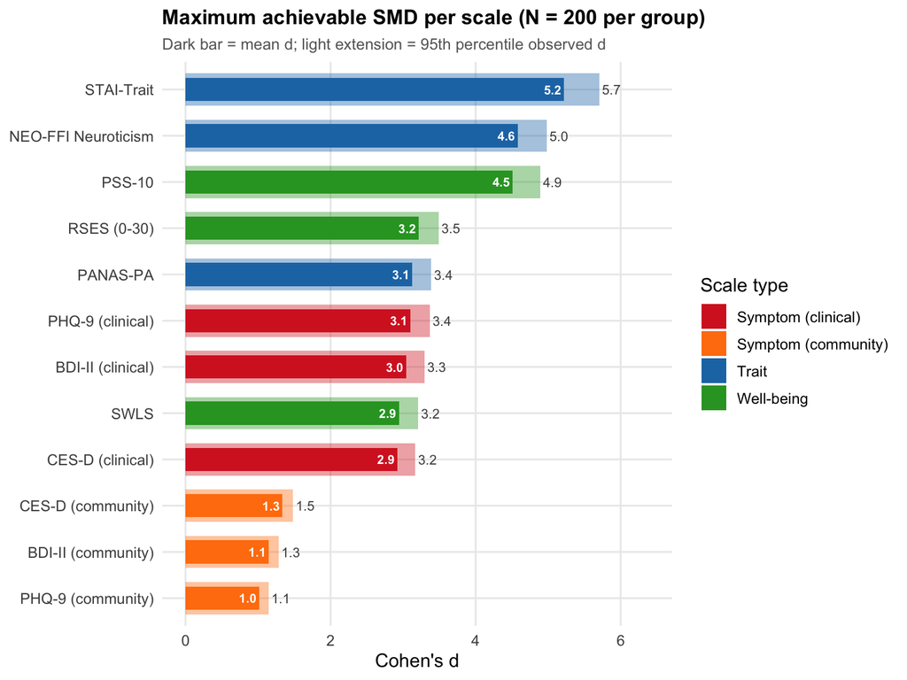

```r
max_per_scale |>
  mutate(scale_name = fct_reorder(scale_name, max_p95_d)) |>
  ggplot(aes(y = scale_name)) +
  # P95 bar (full extent)
  geom_col(aes(x = max_p95_d, fill = scale_type), alpha = 0.4, width = 0.7) +
  # Mean d bar (inner, darker)
  geom_col(aes(x = max_mean_d, fill = scale_type), width = 0.5) +
  # Labels
  geom_text(aes(x = max_p95_d, label = sprintf("%.1f", max_p95_d)),
            hjust = -0.15, size = 3, colour = "grey30") +
  geom_text(aes(x = max_mean_d, label = sprintf("%.1f", max_mean_d)),
            hjust = 1.15, size = 2.8, colour = "white", fontface = "bold") +
  scale_fill_manual(values = scale_type_colours, labels = scale_type_labels) +
  labs(
    title    = "Maximum achievable SMD per scale (N = 200 per group)",
    subtitle = "Dark bar = mean d; light extension = 95th percentile observed d",
    x = "Cohen's d",
    y = NULL,
    fill = "Scale type"
  ) +
  coord_cartesian(xlim = c(0, max(max_per_scale$max_p95_d) * 1.12))
```

### N = 25

At the typical sample size (N = 25 per group), what is the maximum mean and P95 Cohen’s *d* achievable on each scale?

```r
max_per_scale2 <- results |>
  filter(n_per_group == 25) |>
  group_by(scale_name, scale_type, range, range_sd) |>
  summarise(
    max_true_d = max(true_d),
    max_mean_d = max(observed_d_mean),
    max_p95_d  = max(observed_d_p95),
    multiplier = max(observed_d_mean) / first(range_sd),
    mult_p95   = max(observed_d_p95) / first(range_sd),
    .groups = "drop"
  ) |>
  arrange(desc(max_p95_d))

max_per_scale2 |>
  print(n = 20, width = 140)
```

```
## # A tibble: 12 × 9
##    scale_name          scale_type        range range_sd max_true_d max_mean_d
##    <chr>               <chr>             <dbl>    <dbl>      <dbl>      <dbl>
##  1 STAI-Trait          trait                60     6.12       5.20       5.35
##  2 NEO-FFI Neuroticism trait                48     6.23       4.57       4.68
##  3 PSS-10              wellbeing            40     6.45       4.50       4.60
##  4 RSES (0-30)         wellbeing            30     5.66       3.21       3.27
##  5 PANAS-PA            trait                40     5.71       3.12       3.18
##  6 PHQ-9 (clinical)    symptom_clinical     27     4.91       3.09       3.15
##  7 BDI-II (clinical)   symptom_clinical     63     6.3        3.03       3.09
##  8 SWLS                wellbeing            30     4.84       2.94       2.99
##  9 CES-D (clinical)    symptom_clinical     60     6          2.91       2.97
## 10 CES-D (community)   symptom_community    60     7.32       1.33       1.37
## 11 BDI-II (community)  symptom_community    63     7.41       1.14       1.18
## 12 PHQ-9 (community)   symptom_community    27     7.5        1.01       1.05
##    max_p95_d multiplier mult_p95
##        <dbl>      <dbl>    <dbl>
##  1      6.93      0.874    1.13
##  2      5.97      0.751    0.958
##  3      5.85      0.714    0.907
##  4      4.14      0.578    0.731
##  5      4.04      0.557    0.707
##  6      4.03      0.642    0.821
##  7      3.91      0.491    0.621
##  8      3.82      0.618    0.790
##  9      3.74      0.494    0.623
## 10      1.81      0.187    0.247
## 11      1.58      0.159    0.213
## 12      1.43      0.140    0.191
```

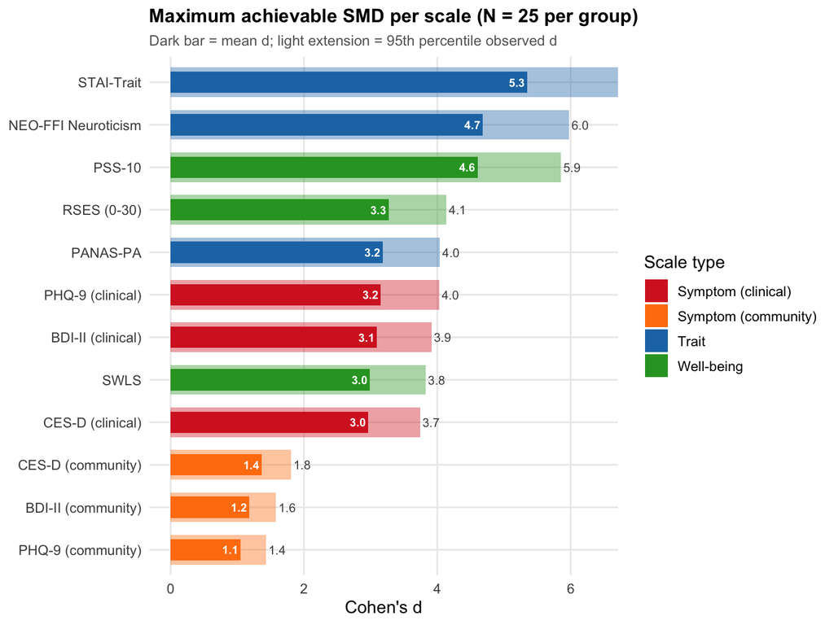

```r
max_per_scale2 |>
  mutate(scale_name = fct_reorder(scale_name, max_p95_d)) |>
  ggplot(aes(y = scale_name)) +
  # P95 bar (full extent)
  geom_col(aes(x = max_p95_d, fill = scale_type), alpha = 0.4, width = 0.7) +
  # Mean d bar (inner, darker)
  geom_col(aes(x = max_mean_d, fill = scale_type), width = 0.5) +
  # Labels
  geom_text(aes(x = max_p95_d, label = sprintf("%.1f", max_p95_d)),
            hjust = -0.15, size = 3, colour = "grey30") +
  geom_text(aes(x = max_mean_d, label = sprintf("%.1f", max_mean_d)),
            hjust = 1.15, size = 2.8, colour = "white", fontface = "bold") +
  scale_fill_manual(values = scale_type_colours, labels = scale_type_labels) +
  labs(
    title    = "Maximum achievable SMD per scale (N = 25 per group)",
    subtitle = "Dark bar = mean d; light extension = 95th percentile observed d",
    x = "Cohen's d",
    y = NULL,
    fill = "Scale type"
  ) +
  coord_cartesian(xlim = c(0, max(max_per_scale$max_p95_d) * 1.12))
```

## Max P95 d by scale and N

The maximum P95 observed *d* across all effect proportions, for each scale and sample size. This is the answer to: “what is the largest *d* a study of this size could plausibly report on this measure?”

```r
max_by_n <- results |>
  group_by(scale_name, scale_type, range_sd, n_per_group) |>
  summarise(
    max_mean_d = max(observed_d_mean),
    max_p95_d  = max(observed_d_p95),
    max_p99_d  = max(observed_d_p99),
    .groups = "drop"
  )

max_by_n |>
  select(scale_name, range_sd, n_per_group, max_p95_d) |>
  pivot_wider(names_from = n_per_group, values_from = max_p95_d, names_prefix = "n_") |>
  arrange(desc(range_sd)) |>
  print(n = 20, width = 150)
```

```
## # A tibble: 12 × 11
##    scale_name          range_sd  n_10  n_15  n_20  n_25  n_30  n_40  n_50 n_100
##    <chr>                  <dbl> <dbl> <dbl> <dbl> <dbl> <dbl> <dbl> <dbl> <dbl>
##  1 PHQ-9 (community)       7.5   1.76  1.56  1.49  1.43  1.38  1.34  1.29  1.20
##  2 BDI-II (community)      7.41  1.92  1.74  1.64  1.58  1.54  1.48  1.44  1.34
##  3 CES-D (community)       7.32  2.20  1.98  1.88  1.81  1.75  1.70  1.66  1.55
##  4 PSS-10                  6.45  7.15  6.42  5.99  5.85  5.73  5.48  5.37  5.08
##  5 BDI-II (clinical)       6.3   4.72  4.29  4.07  3.91  3.82  3.69  3.63  3.42
##  6 NEO-FFI Neuroticism     6.23  7.30  6.54  6.14  5.97  5.80  5.60  5.47  5.18
##  7 STAI-Trait              6.12  8.56  7.73  7.17  6.93  6.79  6.49  6.32  5.94
##  8 CES-D (clinical)        6     4.59  4.10  3.90  3.74  3.67  3.53  3.46  3.28
##  9 PANAS-PA                5.71  4.89  4.44  4.19  4.04  3.93  3.79  3.71  3.52
## 10 RSES (0-30)             5.66  5.04  4.53  4.32  4.14  4.03  3.92  3.82  3.62
## 11 PHQ-9 (clinical)        4.91  4.95  4.44  4.16  4.03  3.89  3.79  3.71  3.50
## 12 SWLS                    4.84  4.65  4.22  3.97  3.82  3.71  3.59  3.50  3.32
##    n_200
##    <dbl>
##  1  1.15
##  2  1.29
##  3  1.48
##  4  4.89
##  5  3.30
##  6  4.98
##  7  5.71
##  8  3.17
##  9  3.39
## 10  3.49
## 11  3.37
## 12  3.21
```

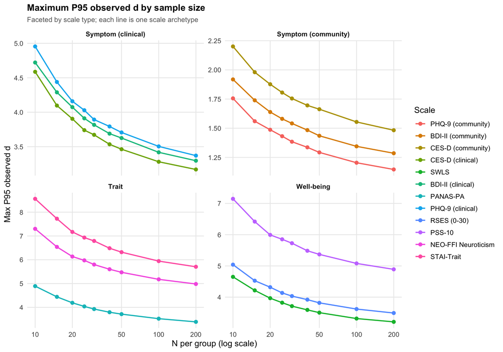

```r
max_by_n |>
  mutate(scale_name = fct_reorder(scale_name, max_p95_d, .fun = max)) |>
  ggplot(aes(x = n_per_group, y = max_p95_d, colour = scale_name)) +
  geom_line(linewidth = 0.8) +
  geom_point(size = 2) +
  facet_wrap(~ scale_type, scales = "free_y",
             labeller = labeller(scale_type = scale_type_labels)) +
  scale_x_continuous(trans = "log10", breaks = c(10, 20, 50, 100, 200)) +
  labs(
    title    = "Maximum P95 observed d by sample size",
    subtitle = "Faceted by scale type; each line is one scale archetype",
    x = "N per group (log scale)",
    y = "Max P95 observed d",
    colour = "Scale"
  ) +
  theme(legend.position = "right")
```

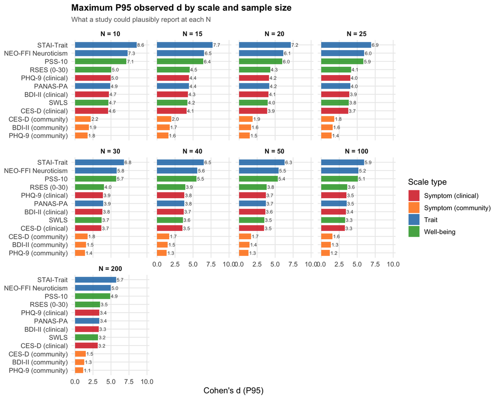

```r
max_by_n |>
  mutate(scale_name = fct_reorder(scale_name, max_p95_d, .fun = max)) |>
  ggplot(aes(y = scale_name, x = max_p95_d, fill = scale_type)) +
  geom_col(alpha = 0.85, width = 0.7) +
  geom_text(aes(label = sprintf("%.1f", max_p95_d)),
            hjust = -0.1, size = 2.5, colour = "grey30") +
  facet_wrap(~ n_per_group, ncol = 4,
             labeller = labeller(n_per_group = \(x) paste("N =", x))) +
  scale_fill_manual(values = scale_type_colours, labels = scale_type_labels) +
  labs(
    title    = "Maximum P95 observed d by scale and sample size",
    subtitle = "What a study could plausibly report at each N",
    x = "Cohen's d (P95)",
    y = NULL,
    fill = "Scale type"
  ) +
  coord_cartesian(xlim = c(0, max(max_by_n$max_p95_d) * 1.15))
```

## P95 multiplier by scale type and N

The multiplier converts the naive Range/SD ratio to the maximum plausible P95 *d*. Multiply the scale’s Range/SD by this factor to get the red-flag threshold.

```r
mult_summary <- max_by_n |>
  mutate(mult_p95 = max_p95_d / range_sd) |>
  group_by(scale_type, n_per_group) |>
  summarise(
    mean_mult_p95 = mean(mult_p95),
    .groups = "drop"
  )

mult_summary |>
  pivot_wider(names_from = n_per_group, values_from = mean_mult_p95, names_prefix = "n_") |>
  print(n = 10, width = 100)
```

```
## # A tibble: 4 × 10
##   scale_type         n_10  n_15  n_20  n_25  n_30  n_40  n_50 n_100 n_200
##   <chr>             <dbl> <dbl> <dbl> <dbl> <dbl> <dbl> <dbl> <dbl> <dbl>
## 1 symptom_clinical  0.841 0.756 0.715 0.688 0.670 0.649 0.636 0.601 0.579
## 2 symptom_community 0.265 0.238 0.225 0.217 0.211 0.203 0.198 0.185 0.176
## 3 trait             1.14  1.03  0.963 0.933 0.909 0.874 0.853 0.806 0.775
## 4 wellbeing         0.986 0.889 0.837 0.809 0.789 0.762 0.744 0.704 0.679
```

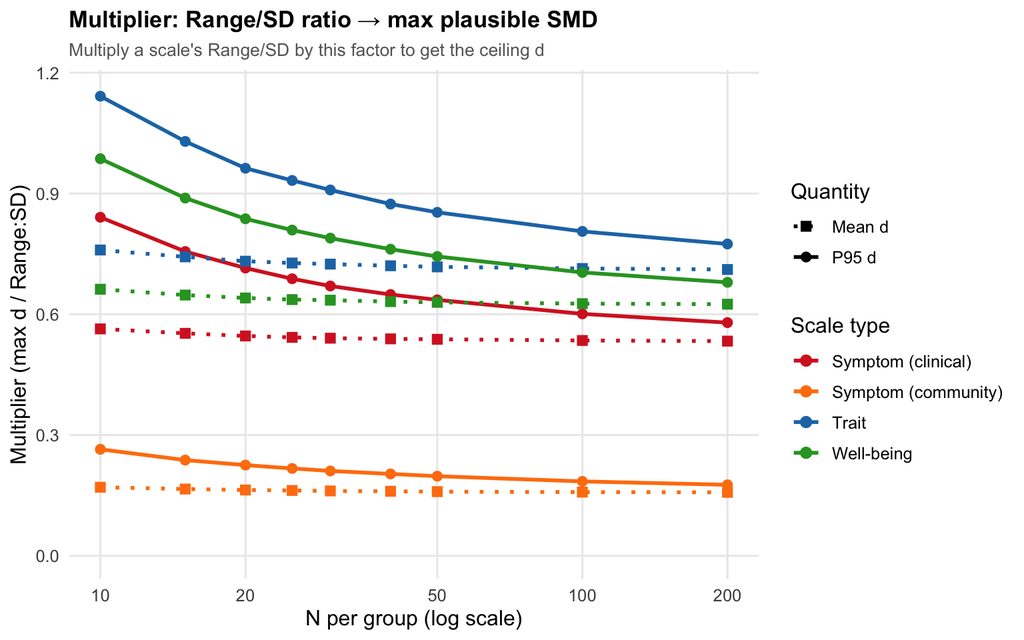

```r
# Also compute mean d multiplier for reference
mult_both <- max_by_n |>
  mutate(
    mult_mean = max_mean_d / range_sd,
    mult_p95  = max_p95_d / range_sd
  ) |>
  group_by(scale_type, n_per_group) |>
  summarise(
    mean_mult_mean = mean(mult_mean),
    mean_mult_p95  = mean(mult_p95),
    .groups = "drop"
  ) |>
  pivot_longer(cols = starts_with("mean_mult_"),
               names_to = "quantity", values_to = "multiplier",
               names_prefix = "mean_mult_") |>
  mutate(quantity = if_else(quantity == "p95", "P95 d", "Mean d"))

mult_both |>
  ggplot(aes(x = n_per_group, y = multiplier, colour = scale_type,
             linetype = quantity)) +
  geom_line(linewidth = 1) +
  geom_point(aes(shape = quantity), size = 2.5) +
  scale_x_continuous(trans = "log10", breaks = c(10, 20, 50, 100, 200)) +
  scale_colour_manual(values = scale_type_colours, labels = scale_type_labels) +
  scale_linetype_manual(values = c("Mean d" = "dotted", "P95 d" = "solid")) +
  scale_shape_manual(values = c("Mean d" = 15, "P95 d" = 16)) +
  labs(
    title    = "Multiplier: Range/SD ratio → max plausible SMD",
    subtitle = "Multiply a scale's Range/SD by this factor to get the ceiling d",
    x = "N per group (log scale)",
    y = "Multiplier (max d / Range:SD)",
    colour   = "Scale type",
    linetype = "Quantity",
    shape    = "Quantity"
  ) +
  coord_cartesian(ylim = c(0, 1.15))
```

## Red flag thresholds

The most practically useful output: the maximum P95 *d* one should expect by scale type and sample size. An observed *d* above these curves should be treated with suspicion.

```r
red_flag <- max_by_n |>
  group_by(scale_type, n_per_group) |>
  summarise(
    mean_p95 = mean(max_p95_d),
    min_p95  = min(max_p95_d),
    max_p95  = max(max_p95_d),
    .groups = "drop"
  )

red_flag |>
  print(n = 20, width = 120)
```

```
## # A tibble: 36 × 5
##    scale_type        n_per_group mean_p95 min_p95 max_p95
##    <chr>                   <dbl>    <dbl>   <dbl>   <dbl>
##  1 symptom_clinical           10     4.75    4.59    4.95
##  2 symptom_clinical           15     4.27    4.10    4.44
##  3 symptom_clinical           20     4.05    3.90    4.16
##  4 symptom_clinical           25     3.89    3.74    4.03
##  5 symptom_clinical           30     3.79    3.67    3.89
##  6 symptom_clinical           40     3.67    3.53    3.79
##  7 symptom_clinical           50     3.60    3.46    3.71
##  8 symptom_clinical          100     3.40    3.28    3.50
##  9 symptom_clinical          200     3.28    3.17    3.37
## 10 symptom_community          10     1.96    1.76    2.20
## 11 symptom_community          15     1.76    1.56    1.98
## 12 symptom_community          20     1.67    1.49    1.88
## 13 symptom_community          25     1.61    1.43    1.81
## 14 symptom_community          30     1.56    1.38    1.75
## 15 symptom_community          40     1.51    1.34    1.70
## 16 symptom_community          50     1.46    1.29    1.66
## 17 symptom_community         100     1.37    1.20    1.55
## 18 symptom_community         200     1.30    1.15    1.48
## 19 trait                      10     6.92    4.89    8.56
## 20 trait                      15     6.24    4.44    7.73
## # ℹ 16 more rows
```

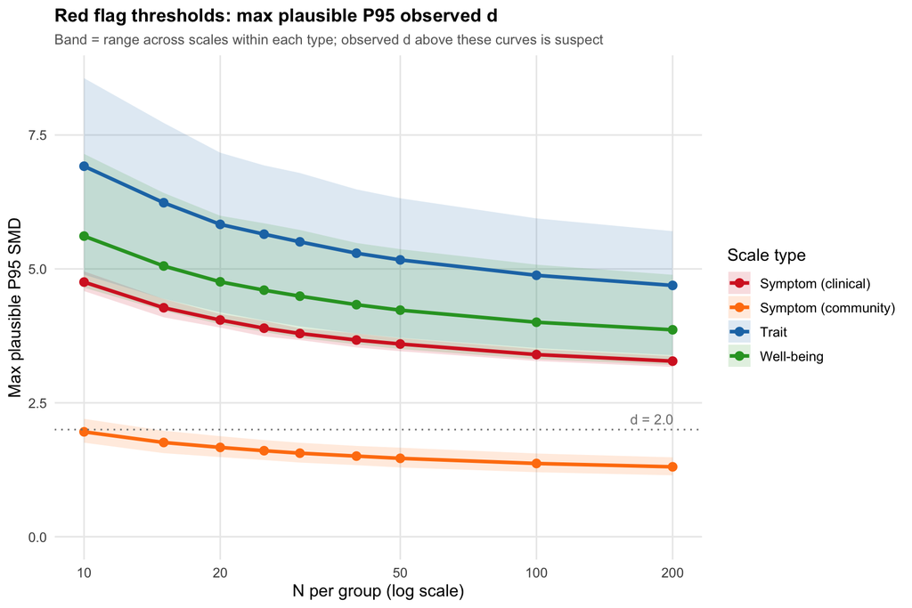

```r
red_flag |>
  ggplot(aes(x = n_per_group, colour = scale_type, fill = scale_type)) +
  geom_ribbon(aes(ymin = min_p95, ymax = max_p95), alpha = 0.15, colour = NA) +
  geom_line(aes(y = mean_p95), linewidth = 1.2) +
  geom_point(aes(y = mean_p95), size = 2.5) +
  scale_x_continuous(trans = "log10", breaks = c(10, 20, 50, 100, 200)) +
  scale_colour_manual(values = scale_type_colours, labels = scale_type_labels) +
  scale_fill_manual(values = scale_type_colours, labels = scale_type_labels) +
  geom_hline(yintercept = 2.0, linetype = "dotted", colour = "grey50") +
  annotate("text", x = 180, y = 2.2, label = "d = 2.0", colour = "grey50", size = 3.5) +
  labs(
    title    = "Red flag thresholds: max plausible P95 observed d",
    subtitle = "Band = range across scales within each type; observed d above these curves is suspect",
    x = "N per group (log scale)",
    y = "Max plausible P95 SMD",
    colour = "Scale type",
    fill   = "Scale type"
  ) +
  coord_cartesian(ylim = c(0, NA))
```

## Effect size ramp

How does the P95 observed *d* grow as the treatment effect increases (i.e., as the treatment mean moves further toward the scale boundary)? Shown for selected scales at small (N = 20), medium (N = 50), and large (N = 200) sample sizes. The shaded band extends from P95 to P99.

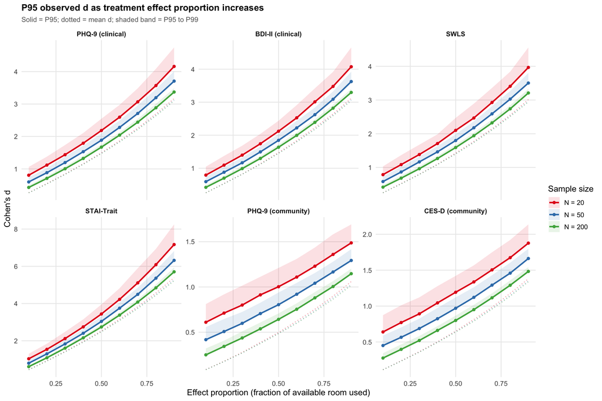

```r
selected_scales <- c("PHQ-9 (clinical)", "BDI-II (clinical)", "SWLS",
                      "STAI-Trait", "PHQ-9 (community)", "CES-D (community)")

results |>
  filter(
    scale_name %in% selected_scales,
    n_per_group %in% c(20, 50, 200)
  ) |>
  mutate(
    n_label    = paste("N =", n_per_group),
    n_label    = fct_reorder(n_label, n_per_group),
    scale_name = factor(scale_name, levels = selected_scales)
  ) |>
  ggplot(aes(x = effect_proportion, colour = n_label, fill = n_label)) +
  geom_ribbon(aes(ymin = observed_d_p95, ymax = observed_d_p99), alpha = 0.12, colour = NA) +
  geom_line(aes(y = observed_d_p95), linewidth = 1) +
  geom_point(aes(y = observed_d_p95), size = 1.5) +
  geom_line(aes(y = observed_d_mean), linewidth = 0.5, linetype = "dotted", alpha = 0.5) +
  facet_wrap(~ scale_name, scales = "free_y", ncol = 3) +
  scale_colour_brewer(palette = "Set1") +
  scale_fill_brewer(palette = "Set1") +
  labs(
    title    = "P95 observed d as treatment effect proportion increases",
    subtitle = "Solid = P95; dotted = mean d; shaded band = P95 to P99",
    x = "Effect proportion (fraction of available room used)",
    y = "Cohen's d",
    colour = "Sample size",
    fill   = "Sample size"
  )
```

## Small-sample noise inflation

How much does small N inflate the *observed* d beyond the true population value? Panel A shows the SD of the sampling distribution of *d* at the maximum effect level. Panel B shows the P95/mean ratio: the factor by which a “lucky” study overestimates the true *d*.

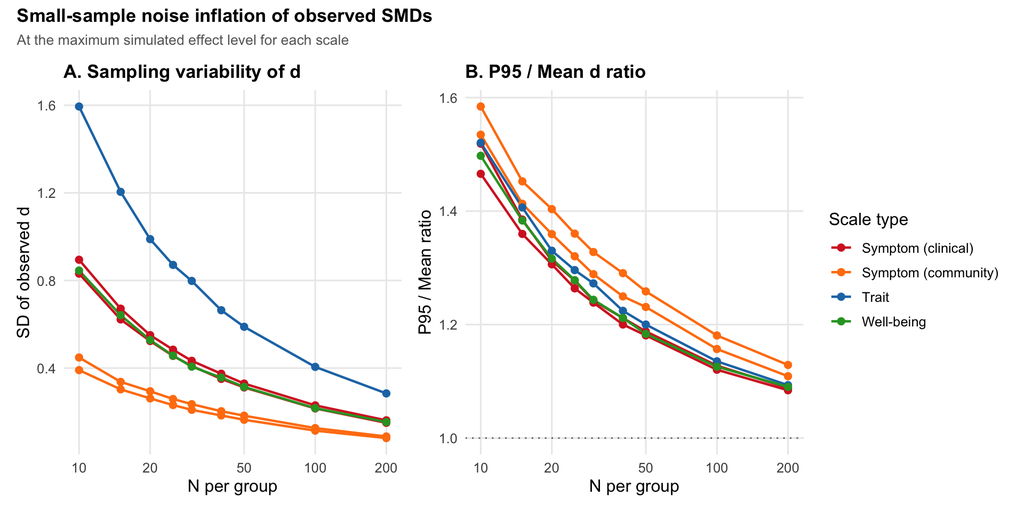

```r
# At max effect proportion per scale
max_props <- results |>
  filter(n_per_group == 200) |>
  group_by(scale_name) |>
  summarise(max_ep = max(effect_proportion), .groups = "drop")

noise_data <- results |>
  inner_join(max_props, by = "scale_name") |>
  filter(effect_proportion == max_ep)

p_a <- noise_data |>
  filter(scale_name %in% selected_scales) |>
  ggplot(aes(x = n_per_group, y = observed_d_sd,
             colour = scale_type, group = scale_name)) +
  geom_line(linewidth = 0.8) +
  geom_point(size = 2) +
  scale_x_continuous(trans = "log10", breaks = c(10, 20, 50, 100, 200)) +
  scale_colour_manual(values = scale_type_colours, labels = scale_type_labels) +
  labs(
    title = "A. Sampling variability of d",
    x = "N per group", y = "SD of observed d",
    colour = "Scale type"
  ) +
  theme(legend.position = "none")

p_b <- noise_data |>
  filter(scale_name %in% selected_scales) |>
  mutate(inflation = observed_d_p95 / observed_d_mean) |>
  ggplot(aes(x = n_per_group, y = inflation,
             colour = scale_type, group = scale_name)) +
  geom_line(linewidth = 0.8) +
  geom_point(size = 2) +
  geom_hline(yintercept = 1.0, linetype = "dotted", colour = "grey50") +
  scale_x_continuous(trans = "log10", breaks = c(10, 20, 50, 100, 200)) +
  scale_colour_manual(values = scale_type_colours, labels = scale_type_labels) +
  labs(
    title = "B. P95 / Mean d ratio",
    x = "N per group", y = "P95 / Mean ratio",
    colour = "Scale type"
  )

# Combine
library(patchwork)
p_a + p_b +
  plot_annotation(
    title    = "Small-sample noise inflation of observed SMDs",
    subtitle = "At the maximum simulated effect level for each scale"
  ) +
  plot_layout(guides = "collect") &
  theme(legend.position = "right")
```

## Stacked bar comparison across N

A direct comparison of mean *d*, P95, and P99 for each scale at three representative sample sizes (N = 20, 50, 200). This makes visible both the true ceiling (mean *d*) and the noise-inflated ceiling (P95, P99).

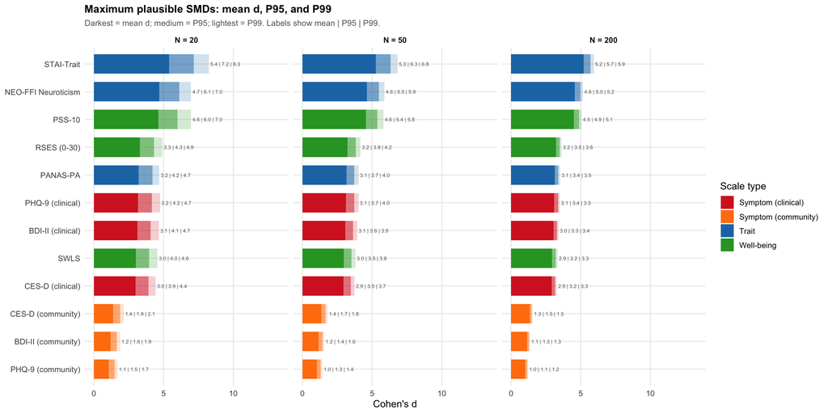

```r
max_by_n |>
  filter(n_per_group %in% c(20, 50, 200)) |>
  mutate(
    scale_name = fct_reorder(scale_name, max_p95_d, .fun = max),
    n_label    = paste("N =", n_per_group),
    n_label    = fct_reorder(n_label, n_per_group)
  ) |>
  ggplot(aes(y = scale_name)) +
  # P99 bar (lightest, full extent)
  geom_col(aes(x = max_p99_d, fill = scale_type), width = 0.7, alpha = 0.2) +
  # P95 bar (medium)
  geom_col(aes(x = max_p95_d, fill = scale_type), width = 0.7, alpha = 0.5) +
  # Mean d bar (darkest, innermost)
  geom_col(aes(x = max_mean_d, fill = scale_type), width = 0.7, alpha = 1.0) +
  # Value labels
  geom_text(aes(x = max_p99_d,
                label = sprintf("%.1f | %.1f | %.1f", max_mean_d, max_p95_d, max_p99_d)),
            hjust = -0.05, size = 2.2, colour = "grey40") +
  facet_wrap(~ n_label, ncol = 3) +
  scale_fill_manual(values = scale_type_colours, labels = scale_type_labels) +
  labs(
    title    = "Maximum plausible SMDs: mean d, P95, and P99",
    subtitle = "Darkest = mean d; medium = P95; lightest = P99. Labels show mean | P95 | P99.",
    x = "Cohen's d",
    y = NULL,
    fill = "Scale type"
  ) +
  coord_cartesian(xlim = c(0, max(max_by_n$max_p99_d) * 1.25))
```

## Range/SD ratio vs max plausible d

The relationship between a scale’s Range/SD ratio and its maximum plausible P95 *d*, with diagonal reference lines showing multiplier values. This demonstrates that the Range/SD ratio alone is insufficient — the scale type (and thus control mean position) fundamentally determines the achievable ceiling.

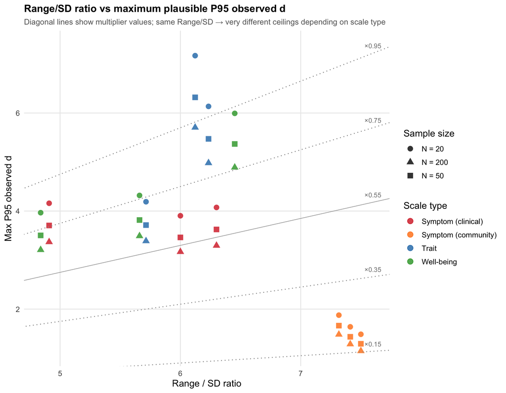

```r
max_by_n |>
  filter(n_per_group %in% c(20, 50, 200)) |>
  mutate(n_label = paste("N =", n_per_group)) |>
  ggplot(aes(x = range_sd, y = max_p95_d, colour = scale_type,
             shape = n_label)) +
  geom_point(size = 3, alpha = 0.8) +
  # Reference lines for multipliers
  geom_abline(slope = 0.15, intercept = 0, linetype = "dotted",  colour = "grey60") +
  geom_abline(slope = 0.35, intercept = 0, linetype = "dotted",  colour = "grey60") +
  geom_abline(slope = 0.55, intercept = 0, linetype = "solid",   colour = "grey60", linewidth = 0.3) +
  geom_abline(slope = 0.75, intercept = 0, linetype = "dotted",  colour = "grey60") +
  geom_abline(slope = 0.95, intercept = 0, linetype = "dotted",  colour = "grey60") +
  # Multiplier labels
  annotate("text", x = 7.6, y = 0.15 * 7.6 + 0.15, label = "×0.15",
           colour = "grey50", size = 3) +
  annotate("text", x = 7.6, y = 0.35 * 7.6 + 0.15, label = "×0.35",
           colour = "grey50", size = 3) +
  annotate("text", x = 7.6, y = 0.55 * 7.6 + 0.15, label = "×0.55",
           colour = "grey50", size = 3) +
  annotate("text", x = 7.6, y = 0.75 * 7.6 + 0.15, label = "×0.75",
           colour = "grey50", size = 3) +
  annotate("text", x = 7.6, y = 0.95 * 7.6 + 0.15, label = "×0.95",
           colour = "grey50", size = 3) +
  scale_colour_manual(values = scale_type_colours, labels = scale_type_labels) +
  labs(
    title    = "Range/SD ratio vs maximum plausible P95 observed d",
    subtitle = "Diagonal lines show multiplier values; same Range/SD → very different ceilings depending on scale type",
    x = "Range / SD ratio",
    y = "Max P95 observed d",
    colour = "Scale type",
    shape  = "Sample size"
  )
```

```r
# write_csv(results, "max_smd_simulation_results.csv")
# write_csv(max_by_n, "max_smd_by_scale_and_n.csv")
```